# Projects in R

Creating Reproducible Analyses

Franz Wortha

Loughborough University

## Outline

- Scope and relevance
- Basics of working with R
- Technical reproducibility
  - Package management
  - Version control with `Git`
- Computational reproducibility
  - Structuring projects
  - Improving code readability Outlook

# Material

**Note**

You can download the course materials from https://github.com/franz-wortha/ADok

# Scope and Relevance

## Scope

- Target audience
  - “Content-focused” scientists
  - Entry to intermediate level applied R user
- Aims
  - Raise awareness of workflow-related issues
  - Showcase *selected* solutions
  - Provide an understanding *how* the solutions work
  - Enable you to **help yourself** and apply skills to **your workflow**

**Note**

- This course is opinionated

## Reproducibility

From [Wikipedia](https://en.wikipedia.org/wiki/Reproducibility)

> Reproducibility, closely related to replicability and repeatability, is a major principle underpinning the scientific method. For the findings of a study to be reproducible means that results obtained by an experiment or an observational study or in a statistical analysis of a data set should be achieved again with a high degree of reliability when the study is replicated.

> With a narrower scope, reproducibility has been introduced in computational sciences: Any results should be documented by making all data and code available in such a way that the computations can be executed again with identical results.

## Range of Reproducibility

- Adequate level depends on the project, constraints, etc.
- Higher levels $\rightarrow$ more complex technical setup
- This workshop:

[figure not shown]

R

[figure not shown]

renv

[figure not shown]

Git

[figure not shown]

GitHub

[figure not shown]

docker

✅

✅

✅

❌

❌

# Basics of Working with R

## R

- Programming language
- Primarily used for statistical and graphics computing
- Can be used through different applications
  - Terminal/Console
  - Integrated development environments (IDEs, e.g., VS Code)
  - Interactive notebooks (Jupyter)

## Rstudio I

- IDE specialized on R (and Python)
- Collection of tools that enhance work with R
  - Console
  - Editor with syntax highlighting and code completion
  - Graphing tools
  - `Git` integration

## Rstudio II

- Consists of multiple panes/panels
  - Source/script
  - Console and terminal
  - 2 panes with further functionality
    - Environment
    - Files
    - `Git`
    - Help
    - Packages
    - Plots
- Layout can be customized via `Tools > Global Options > Pane Layout`

## Console and Terminal

- Console refers to the R console
  - Equivalent to opening R in a terminal window
  - Allows direct interaction with R
    - E.g., Complete mathematical operations: `1 + 2 - 3 * 4 / 5`
    - Has history but all interactions are lost upon closing RStudio
  - Terminal lets you interact with your operating system’s shell
    - Mac/Linux: typically `bash` or `zsh`
    - Windows: `Command Prompt` or `Windows PowerShell`
    - Can be used for manual `Git` integration

## Source/Scripts

- Scripts are edited here
  - They are text files and can be saved
- Has incorporated highlighting and formatting tools
  - e.g., `Cmd/Ctrl + Shift + A` formats code in R conventions
- The primary way we write code
- R Studio Code lets you seamlessly run this code
  - Graphical user interface: `Run Button`
  - Keyboard shortcuts: `Cmd/Ctrl + Return`
  - Selected code is send to the console and evaluated

## Further Panes I

- Environment
  - Overview of objects in the working environment
  - Useful to inspect data, models etc.
  - GUI tool for data import
- Files
  - File manager
- Help
  - Documentation and help pages
  - Documentation will be displayed here if help is called from R (`?function_name`)

## Further Panes II

- Packages
  - Overview of installed and loaded packages
  - Can be used to load and update packages via GUI
- Plots
  - Graphs created in R are displayed here
  - GUI options for export etc.
- `Git`
  - Version control
  - A GUI tool with most common `Git` commands

## Hidden files and folders

- Most of the tools we cover use hidden files or folders
- Works similarly across file systems (`Mac: Finder`, `Win: Explorer`)
  - Per default elements with a leading `.` will not be displayed
  - Can be shown via shortcut (`Cmd + Shift + .`, `Alt + V` then `H + H`)
- Commonly used by applications to save settings
  - Called dotfiles
  - E.g., Rstudio settings on Mac are saved under `~/.config/rstudio/rstudio-prefs.json`

# RStudio walkthrough

# R

## Working with R

> To understand computations in R, two slogans are helpful:
> - Everything that exists is an object.
> - Everything that happens is a function call.

[John Chambers (creator of the S programming language)](https://riegersven.github.io/data-doc-workshop-2023/intro-r-rstudio.html)

## Data Structures

- Vectors
- Lists
- Data Frames

## Vectors

- One-dimensional array with one data type
- Created with `c()` (combine) function

```r
c(1, 2, 3, 4)
```

```
[1] 1 2 3 4
```

- Elements can be accessed via their index
  - R starts indices with 1

```r
c(1:4)[3]
```

```
[1] 3
```

## Named Vectors

- Make elements accessible by name
- Getting the value(s) requires an extra steps

```r
one_to_three <- c("one" = 1, "two" = 2, "three" = 3)
one_to_three
```

```
  one   two three
    1     2     3
```

```r
# This doesn't work
# one_to_three["two"] + 1
# With name
unlist(one_to_three["two"]) + 1
```

```
two
  3
```

```r
# Without name
unname(one_to_three["two"]) + 1
```

```
[1] 3
```

## Lists

- List
  - (Named) collection of objects
  - Can contain multiple data types
  - Objects can be accessed via their position or name
  - Resembles dictionaries from other languages (e.g., Python)
  - Commonly used for results of analyses

```r
list(`1` = "one", "range" = c(2:4), "matrix" = matrix(1:4, nrow = 2))
```

```
$`1`
[1] "one"

$range
[1] 2 3 4

$matrix
     [,1] [,2]
[1,]    1    3
[2,]    2    4
```

## Data Frames

- Data Frame
  - Named table
  - Multiple data types
    - Consistent within columns (e.g., one non-numeric value $\rightarrow$ character column)
  - Columns can be accessed via their name (`$`, `[]` or `.`)
  - Rows and columns can be accessed via their index

```r
numbers <- data.frame("number" = c(1:4), "letter" = c("a", "b", "c", "d"))
numbers$number
```

```
[1] 1 2 3 4
```

```r
numbers[, "letter"]
```

```
[1] "a" "b" "c" "d"
```

```r
numbers[4, 2]
```

```
[1] "d"
```

## Functions I

- A function is a bundled unit of code that performs a specific task
- Functions generally
  - Have a name
  - Take arguments
  - Return (a) value(s)
- In short: A function uses a predefined procedure to create (a) value(s) based on (an) argument(s).

## Functions II

- Advantages of functions
- Functions in R are a great way to improve your R workflows
  - Repeat tasks without the risk of copy and paste errors
  - When the task needs adjustments, changes only need to be made in one place
  - Objects and variables defined within a function are kept within the function scope unless specified differently
  - Improve readability of your code

## Functions III

- Are created with the `function` keyword
- Can have no arguments
- Arguments can have default values
- It is considered good practice to always include a return value
  - If none is required, the function can still return `TRUE`, `FALSE`, or `NULL`

```r
say_hello <- function() {
  return("Hello, I am a function!")
}
say_hello()
```

```
[1] "Hello, I am a function!"
```

```r
say_hello_to <- function(who = "world"){
  hello_to <- paste("Hello, ", who, "!", sep = "")
  return(hello_to)
}
say_hello_to()
```

```
[1] "Hello, world!"
```

```r
say_hello_to("workshop attendees")
```

```
[1] "Hello, workshop attendees!"
```

# Function excercise

Create a function that returns a named vector or list with the mean, sd, min and max of vector.

**Tip**

- Use a `named vector` or `list` as return value.

# Technical reproducibility

## Package Management - Relevance I

- Most analyses you will conduct will require the installation of additional packages
  - Developed decentralized by different groups
  - Often require functions from one another (dependencies)
  - Updated over time in vastly differing intervals Potential issues
  - Required packages can be incompatible
    - E.g., two packages require different versions of a dependency
  - Functions were changed $\rightarrow$ old scripts don’t run after update
  - Default values are changed $\rightarrow$ results change
  - R’s functionality gets updated $\rightarrow$ packages may not work at all

## Package Management - Relevance II

- Reproducibility
  - Sharing data and scripts is at the core of open science efforts
  - Hardly achievable for analysis when script can’t be run
    - On other machines
    - At later time points
- Save unnecessary effort when
  - Reusing parts of old scripts for new projects
  - Share scripts with colleagues

## Projects

- A solution to most of the aforementioned issues
- Idea: Separate package libraries for each project
  - Only install required packages for a project
  - Breakage in a project does not affect other projects
  - Slimmer libraries $\rightarrow$ package conflicts less likely
- A common approach in programming-related work
  - Most IDEs include useful tools for project-based workflows

## What is `renv`?

- R package that helps to manage package versions and dependencies in projects
- Aims
  - Enable robust, local projects
  - Enhance reproducibility
- Key functionalities
  - Automatically documents installed package versions
  - Provides a means to revert project-breaking changes
  - Scans project for required packages and advises installation of missing packages
  - Tools for package management (e.g., a convenient way to update all packages)

## How does `renv` Work?

- `renv` creates key files and folders when initiated.
  - `renv` folder
    - Subfolders for libraries and settings
    - `activate.R` script, which ensures that the local project library is used for the R session when it’s executed
  - `.Rprofile`
    - File that can be used to configure R functionality as/before it starts
    - Here: `source("renv/activate.R")`
  - Version of installed packages is saved in `renv.lock`

## Project-based Workflow with `renv`

1. Set up `renv`

```r
renv::init()
```

2. Work on project (install packages etc)

```r
renv::install("package I need")
```

3. Save the packages (incl. version used)

```r
renv::snapshot()
```

4. Change/update packages when necessary
- Successful: repeat 3
- Broken project: `renv::revert` to restore last snapshot

```r
renv::revert()
```

## Further Useful Tools

- Check the status of the current environment
  - Changes that are not yet recorded in `renv.lock`
  - Packages that are required but not installed

```r
renv::status()
```

- Detect packages that are required

```r
renv::dependencies()
```

- Copy required packages from local R installation rather than downloading them new

```r
renv::hydrate()
```

# `renv` Demo and Exercise

## `renv` Exercise

**Warning**

Don’t use your home directory or an existing project folder for this exercise.

- Initialize a new R environment in a new folder
- Create an R script in the folder
  - Add code to load two uninstalled libraries
  - Don’t execute that script
  - Close the script
- Check the dependencies of the `renv`
- Install libraries and snapshot the environment
- Install an unnecessary library and revert the install

## Summary

- `renv` enables easy project-based package management
- Project-breaking installations can be reverted
  - Can only revert to the previous version of `renv.lock`
  - The extent of setback depends on regular use of `snapshot`
- There is no easy solution if incompatible packages are required for a project
- Issues after extensive changes are hard to track and revert
- There is no solution if packages become unavailable or do not work with R version(s)

# Version Control with `Git`

## Trying to Keep Track of Changes

- A real-life example

```r
# new edit 'P1': 16/03/2022 (script check)
# new edit 'P2': 17/03/2022 (uniform presentation based on 'P1's' comments)
# new edit 'P2': 24/03/2022 'P2' noticed there are some columns were no check for NA's is happening.
```

- Good idea, room for improvement in the execution.

## Scope

- This section will focus on the minimal basics required to use `Git` for version control
  - Emphasis will be on using `Git` locally
  - Only commands essential for working on simple analysis projects will be covered
- Reasons for this limitation include
  - GitHub requires an account for remote repository hosting
  - Remote repositories may not comply with data security and privacy restrictions
    - Infrastructure varies by institution, with some preferring locally hosted repositories
  - Integration of GitHub varies across different IDEs
- Approach can be easily extended to include remote repositories such as GitHub or GitLab

## Git

- `Git` is a version control tool
- Mostly known through the remote repository GitHub
- Tracks changes in files
  - ‘Checkpoints’ have to be manually set
  - Mainly used for coding, can be used for documents as well (e.g., manuscripts)
- Allows for the creation of alternative branches to test changes
  - Successful modifications can be merged into the main project
  - Failed tests can be discarded without impacting the project

## Setting up `Git`

- [Download](https://git-scm.com/downloads) and install `Git`
  - You can check if `Git` is installed by typing `Git` in in your shell
  - This will show a brief overview of `Git` functions

```bash
git
```

- Set your username and email
  - This is not a log in/set up of an account
  - Used to track who committed changes

```bash
git config --global user.name "Your Name"
git config --global user.email "your@email.com"
# Show username and email
git config user.name
git config user.email
```

## A Simplified `Git` Workflow

1. Initialize `Git` (only required when starting a new project)

```bash
git init
```

2. Work on project
3. Add files for commit

```bash
# Add specific files
git add script1.R script2.R script1.R
# Add all changed files to commit
git add .
```

4. Commit changes

```bash
git commit -m "Added demonstration scripts"
```

5. Repeat 2-4

## Reverting an Erroneous Commit

1. Get the commit hash of commit that broke project

```bash
git log
```

2. Revert all changes of that commit
- This reversal is kept as a new commit
- Information for the breaking commit are kept in the version history

```bash
git revert f07ceb7ab03b6b50d2f65c67b6cd8b280f0f2912
```

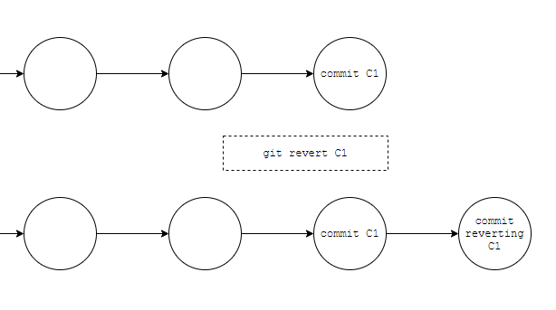

[Source](https://www.freecodecamp.org/news/git-revert-commit-how-to-undo-the-last-commit/)

## Fixing Issues Before They are Committed

- Realize issue before files are added changes are committed
  - Revert uncommitted changes

```bash
# Revert uncommitted changes to a specific file
git checkout -- file_that_broke_my_project.R
# Reverting all uncommitted changes
git checkout -- :/
```

## Testing on New Branches

1. Make sure you are up to date
2. Create new branch

```bash
git branch trying_something_new
```

3. Switch to new branch

```bash
git checkout trying_something_new
```

4. Implement and test changes
5. They don’t work $\rightarrow$ switch to back main branch and delete branch

```bash
git checkout main
git branch -d trying_something_new
```

5. They work $\rightarrow$ switch to main branch and merge branches

```bash
git checkout main
git merge trying_something_new
```

## Ignoring Files

- You can tell `Git` to ignore files and folders
  - These never show up in `git status`, even if modified
- This is achieved with the `.gitignore` file
  - Files can be explicitly listed
  - Patterns can be employed to encompass multiple files
    - All files in a folder (data/**)
    - All files of a type (*.sav)
- `renv::dependencies` skips any file listed in `.gitignore`

## Further Material

- This intro to `Git` was inspired by [this video](https://www.youtube.com/watch?v=USjZcfj8yxE) and the [corresponding material](https://zarkom.notion.site/zarkom/Introduction-to-Git-ac396a0697704709a12b6a0e545db049)
- [Git Cheat Sheet](https://training.github.com/downloads/github-git-cheat-sheet.pdf)

# `Git` Demonstration

`Git` workflow using the terminal and [GitHub Desktop](https://desktop.github.com/)

# Analysis Projects with RStudio

- Open a new project in the destination folder
  - `File > New Project`
- Initialize version control using `Git`
- Initialize `renv` for package management
  - Check `git version control` and `use renv`
- Install necessary packages
  - Capture package versions with `renv`
  - Stage and commit changes to `renv` using `Git`
- Set up the folder structure
- Import required data
- Begin working on the project

## Summary

# Computational Reproducibility

## Random Number Generation

- Some models and functions involve random processes
  - Results change when repeated
  - E.g., splitting data into n random subsets to cross-validate an exploratory factor analysis
- Example: drawing 10 values from a Z-Distribution

```r
rnorm(10)
```

```
 [1]  0.3980551 -0.1535008 -0.9854192  0.4492765 -0.9652950 -0.7776515
 [7]  1.8608108  0.9715150 -0.0426306  0.8170880
```

```r
rnorm(10)
```

```
 [1] -0.64440331 -0.41400219  1.24523996  0.01433849 -0.30312183 -0.91995314
 [7] -0.82342926 -0.19365322  0.62603892 -2.67509060
```

## Setting seeds

- Sets a “fixed” seed that makes random processes reproducible

```r
set.seed(1)
rnorm(10)
```

```
 [1] -0.6264538  0.1836433 -0.8356286  1.5952808  0.3295078 -0.8204684
 [7]  0.4874291  0.7383247  0.5757814 -0.3053884
```

```r
set.seed(1)
rnorm(10)
```

```
 [1] -0.6264538  0.1836433 -0.8356286  1.5952808  0.3295078 -0.8204684
 [7]  0.4874291  0.7383247  0.5757814 -0.3053884
```

- Use random seeds when reporting such results
- Make sure that the results do not vastly change when seed is changed
  - E.g., test model/function several time without or with different random seeds
- If there are substantial fluctuations, repeat process several times
  - Aggregate results or report fluctuation

# Structuring Projects

## Paths

- Absolute paths make it impossible to run script on other machines without changing them (e.g., “/Users/this/path/wont/work/for_you.csv”)
- Key advantage of R projects: Console and terminal automatically start in project folder
  - Relative paths can be used (e.g., “./data/my_example_file.csv”)
- `here` package can be used to overcome differences in OS

```r
library(here)

# Create compatible path for current OS
file_path <- here("data", "raw", "example_logfile.csv")
file_path
```

```
[1] "/Users/lnfdw/GitLab/R_workshop/data/raw/example_logfile.csv"
```

```r
# Could be used to load a file
# log_file <- read.csv(file_path, stringsAsFactors = FALSE)
```

## Folder Structure in Projects I

- Hard to find relevant files if all files and scripts are at the top level of your folder
- Projects should follow clear structure
- Example
  - Project
    - Data
      - Raw
      - Processed
    - Scripts
    - Output
      - Graphs
      - Tables

## Folder Structure in Projects II

- The structure depends on your preferences and the project
- Recommendation: Keep top level as clean as possible (e.g., only folders, README.md etc.)
- [Resource](https://www.youtube.com/watch?v=GeN-qqNLLsM) that explains three ways to create the folder structure
  - In your file explorer
  - Using R
  - From the terminal

**Note**

Avoid nesting projects within a projects.

## Organizing Scripts

- All libraries should be loaded at the start of the script
  - Loading packages just before they are used is error prone when changes are made
- There is not agreed upon convention for their order
  - In order of their first use
  - Alphabetical
  - With masking in mind (e.g., load packages whose functions should not be masked last)

## Splitting Scripts and Sourcing

- Scripts should be split if they get extensive and include multiple key steps
  - E.g., Functions, data import and pre-processing, analysis
- `source` if they create multiple objects necessary for subsequent steps
  - Masking and similar issues may occur
- If they only create a data set (e.g., during pre-processing) saving the result of that script as a file is preferable
- Objects can also be saved as R data
  - For large computations that can’t be saved in standard file formats

# Improving Code Readability

## Piping and Nesting

- Piping: “Chaining” operations through a pipe operator
- The value of the left-hand side is used as the first argument of the right-hand side
  - Placeholder can be used to use the value as a different argument in the right-hand side
- Two implementations
  - `%>%` (`dplyr`/`tidyverse`)
  - `|>` (Base R [version 4.1.0](https://cran.r-project.org/doc/manuals/r-devel/NEWS.html) or later)
- Can greatly improve readability of nested function calls
  - Ideal for data manipulation

## Nesting - Example

- Can you quickly tell what this code does?

```r
summarise(
  group_by(filter(
    rename_with(iris, tolower), species != "setosa"
  ), species),
  sepal_length = mean(sepal.length),
  petal_width = mean(petal.width)
)
```

## Piping - Example

- How about now?

```r
iris %>%
  rename_with(tolower) %>%
  filter(species != "setosa") %>%
  group_by(species) %>%
  summarise(sepal_length = mean(sepal.length),
            petal_width = mean(petal.width))
```

```
# A tibble: 2 × 3
  species    sepal_length petal_width
  <fct>             <dbl>       <dbl>
1 versicolor         5.94        1.33
2 virginica          6.59        2.03
```

- Pipe-related resources
  - [dplyr](https://dplyr.tidyverse.org/): powerfull data manipluation with pipes
  - [rstatix](https://rpkgs.datanovia.com/rstatix/): common statistical models with focus on piping

## Commenting Code

- Comments are lines in scripts that are not evaluated
- IDEs (e.g., RStudio) will highlight comments
- R + RStudio
  - In R, comments start with `#`
  - Keyboard shortcut: `Cmd/Ctrl + Shift + C`
- Comments can be used between lines or at the end of lines

```r
# Show that statement if not printed when commented out
# print("This is an example for a comment")
print("That comment didn't stop me!") # Code not 'disabled'
```

```
[1] "That comment didn't stop me!"
```

## Importance of Comments

- Readable and comprehensible code is essential for a reproducible workflow
- Comments are essential to efficiently resume your projects
- Enable others to work with your code more easily
- Commenting your code clearly takes practice and effort

## Ideas to Effectively Comment

- There are no clear guidelines for commenting
- Be concise and precise
- Point out specifics that are not easily detectable
- State what a code snippet does

```r
# Get the absolute path of this file via Rstudioapi
# Only run if rstudioapi is installed
# library(rstudioapi)
# if (require(rstudioapi)){
#   dirname(rstudioapi::getSourceEditorContext()$path)
# }
```

- Don’t state obvious things (R’s documentation handles that)
- Point out dependencies
- Find a commenting style that works for you

## Naming I

- Often overlooked when improving coding
- Less need to limit length of variable names with help of development tools (i.e., code completion)
- Variable and object naming makes code more readable
  - Can work like comments
- Common conventions
  - camelCase
  - Use_of_underscores

## Naming II

- Common in R
  - `.` is often used instead of `_`
    - e.g., `read.csv`
    - Clashes with naming conventions in other languages, particularly object-oriented languages (e.g. python)
- Consistency is important
  - Functions with similar functionality should follow the same convention
  - Different conventions can be used for different objects (e.g., [BlueStyle for Julia](https://github.com/invenia/BlueStyle))

## Outlook

- Project-based workflows are applicable to most languages
- Python
  - [Spyder](https://www.spyder-ide.org/) is it’s equivalent to RStudio
  - [venv](https://docs.python.org/3/library/venv.html) works very similar to `renv`
    - Installing are still made with `pip`, but the libraries are saved in the virtual environment
  - pyenv can further change Python versions easily
- Julia
  - [VSCode](https://code.visualstudio.com/) is the officially supported IDE
  - Has a built in project mode (`julia -project`)
  - [Julia-up](https://github.com/JuliaLang/juliaup) enables easy switching between Julia versions

# Thank you for your attention!

Questions? Contact me!

[figure not shown]

Projects in R | Franz Wortha